# Bilgi Yönetim Sistemleri - Bitirme Projesi Rapor :

Hamza Alpaslan 190401053

Ömer Faruk Bozkaya 200104057

Nazik Ashyrova 190401115

Hameem Alyafai 190401082

2024-05-23

# Q1: İş probleminin tanımı

Film öneri işletmesi olarak , kullanıcıların izlediği filmler üzerinden film değerlendirmesi yaparak kullanıcılara önerilerde bulunuyoruz . Veri seti olarak **TMDb API** kullanıyorduk fakat veri miktarının az olması nedeniyle veri setimizi değiştirdik . Yeni veri setimizi **Kaggle**’dan bulduk ve bundan sonra o veri setini kullanacağız . BYS platformu olarak **Wordpress** kullanmamızdaki nedenlerimiz ; Kullanıcı dostu arayüze sahip olması , Geniş tema ve eklenti desteğinin bulunması , açık kaynak olması ve yaygın kullanıma sahip olmasıdır . Platformumuzu oluştururken Worpress’in şu pluginleri kullanmaktayız

- **TablePress**: WordPress sitenize kolayca tablo eklemenizi sağlayan bir eklentidir. Bu eklenti ile filmler arasından arama yapıp görüntüleyebiliyoruz.
- **WPForms**: WordPress sitenizde formlar oluşturmanıza olanak tanıyan bir sürükle ve bırak form oluşturucu eklentisidir.Bu eklentiyle kullanıcılardan bir film girdisi alıyoruz.

# Q2: Veri Setinin Detayları

IMDb’nin en iyi 1000 film ve TV şovu verilerini içermektedir. Veri seti, [Kaggle’dan](https://www.kaggle.com/datasets/harshitshankhdhar/imdb-dataset-of-top-1000-movies-and-tv-shows) alınmıştır.

### Veri Setinin İçeriği

Veri seti aşağıdaki sütunları içermektedir:

- **Poster_Link**: Filmin veya TV şovunun posterinin URL’si
- **Series_Title**: Filmin veya TV şovunun başlığı
- **Released_Year**: Yayınlanma yılı
- **Certificate**: Sertifika (ör. PG-13, R)
- **Runtime**: Süre
- **Genre**: Tür
- **IMDB_Rating**: IMDb puanı
- **Overview**: Filmin veya TV şovunun özeti
- **Meta_score**: Metacritic puanı
- **Director**: Yönetmen
- **Star1**, **Star2**, **Star3**, **Star4**: Başroldeki oyuncular
- **No_of_Votes**: Oy sayısı
- **Gross**: Brüt gelir

### Veriyi Toplayan/Yaratanlar

Bu veri setini oluşturan Harshit Shankhdhar, IMDb web sitesinden scraping yaparak bu verileri elde etmiştir. Scraping, web sitelerindeki bilgileri programlı bir şekilde toplayarak yapılandırılmış veri haline getirme işlemidir.

### Veride Yapılan Değişiklikler

**Word press’de resimlerin gösterimi**: Poster resimleri veride link şeklinde bulunuyordu. Word press’de bu resimlerin gözükebilmesi için resimleri html dilinde siteden çekmek gerekiyordu. Exxelde poster linki sutunundaki bütün linklerin başına <img src=” şeklinde ekleme yaptık.

#### örnek:

https://m.media-amazon.com/images/M/MV5BMjAxMzY3NjcxNF5BMl5BanBnXkFtZTcwNTI5OTM0Mw@@._V1_UX67_CR0,0,67,98_AL_.jpg

Bu linkin sonuna ve başına html kodlarını yazınca sitede resim gözükebilir hale geliyor

```
<img src="https://m.media-amazon.com/images/M/MV5BMjAxMzY3NjcxNF5BMl5BanBnXkFtZTcwNTI5OTM0Mw@@._V1_UX67_CR0,0,67,98_AL_.jpg">
```

# Q3: Veri seti keşifsel analizi

### Veri Setinin İçeriği

Veri seti aşağıdaki sütunları içermektedir, sütunların veri tipleri: **Runtime** ve **Released_Year** character tipinden numeric tipine dönüştürüldü.

- **Poster_Link**: character
- **Series_Title**: character
- **Released_Year**: numeric
- **Certificate**: character
- **Runtime**: numeric
- **Genre**: character
- **IMDB_Rating**: double
- **Overview**: character
- **Meta_score**: double
- **Director**: character
- **Star1**, **Star2**, **Star3**, **Star4**: character
- **No_of_Votes**: double
- **Gross**: numeric

[figure not shown]

Vei setimiz imdbnin en yüksek puan alan 1000 filmini içeriyor. Bu 1000 film içinde en çok sayıda olanlar drama filmleri. Demek ki insanlar drama filmlerine yüksek puanlar veriyor

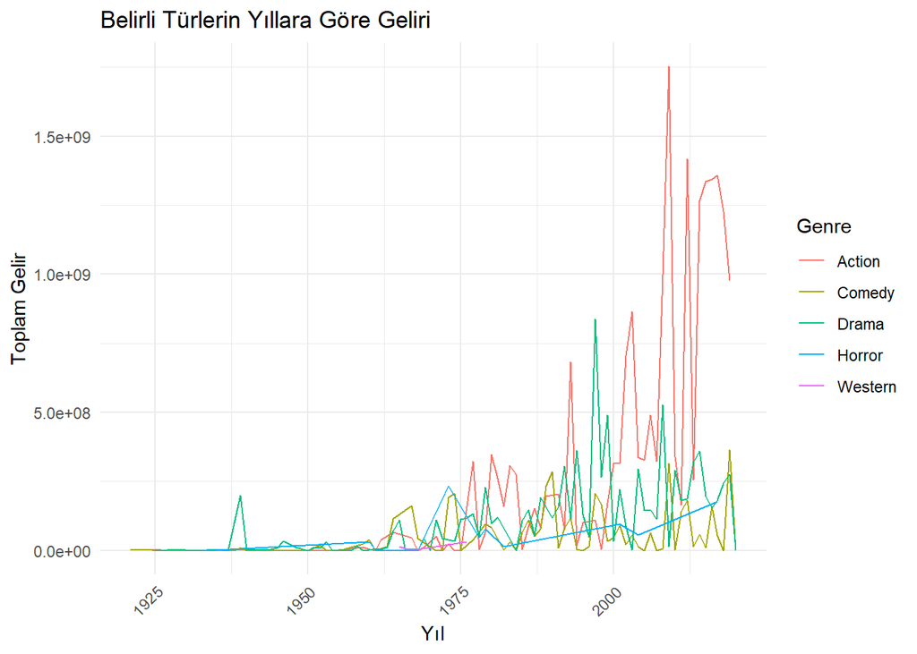

Bu grafiğe ve yukardaki grafiğe bakarak: İnsanlar drama filmlerini seviyor ama aksiyon filmlerine para harcıyor yorumunu yapabiliriz.

```
## # A tibble: 548 × 3
##    Director           ortalama_puan toplam_gelir
##    <chr>                      <dbl>        <dbl>
##  1 Frank Darabont              8.78    438745591
##  2 Irvin Kershner              8.7     871425201
##  3 Lana Wachowski              8.7     342959860
##  4 George Lucas                8.6     968220420
##  5 Roberto Benigni             8.6     172794741
##  6 Fernando Meirelles          8.6      15126794
##  7 Masaki Kobayashi            8.6             0
##  8 Sudha Kongara               8.6             0
##  9 Thomas Kail                 8.6             0
## 10 Roger Allers                8.5    1268351331
## # ℹ 538 more rows
```

Hangi yönetmenin filmlerinin en çok beğenildiği ve hangi yönetmenin filmlerinin daha çok para kazandırdığına bakarak. Bir sonraki çekilen filmin hangi yönetmen tarafından yönetileceğine karar verilebilir.

# Q4: Veri setinin BYS platformuna ithali

Veri setimizi Worpress’e **table press** ile *.csv* formatında yükledik .

# Q5: Yapılması Planlanan Veri Analizi

### Projenin Hedefi

Film puanlama sitesi projesinin ana hedefi, kullanıcıların film izleme ve puanlama alışkanlıklarını analiz ederek, kişiselleştirilmiş öneriler sunmak ve reklam stratejilerini optimize etmektir. Ayrıca, film stüdyolarına gelecekte çekilecek filmler için stratejik kararlar almalarına yardımcı olacak trend analizleri sağlamaktır.

### Kritik Analizlerin Planlaması

#### 1. Veri Setlerinin Birleştirilmesi

- **Veri Kaynakları:** Kaggle’dan bulduğumuz imdb data ile film bilgileri (film adı, tür, oyuncular, yönetmen, puanlar vb.).

#### 2. Veri Setinin Kategorilere Ayrılması

- **Analiz Yöntemleri:** Her kategori için izlenme ve puanlama eğilimleri incelenecek. Bu, farklı kullanıcı segmentleri için özelleştirilmiş öneri ve reklam stratejileri geliştirilmesini sağlayacak.

#### 3. Grafiksel ve İstatistiksel Analiz

- **Grafikler:** Kullanıcıların izleme alışkanlıkları, film türlerine göre dağılımlar ve zaman içindeki trendler grafiklerle gösterilecek.
- **İstatistiksel Operasyonlar:** Ortalama puanlar, medyan değerler ve diğer temel istatistiksel analizler yapılacak. Bu analizler, kullanıcı davranışlarını daha iyi anlamak ve trendleri tespit etmek için kullanılacak.

#### 4. Klasik İstatistiksel Operasyonlar

- **Ortalama ve Median Hesaplamaları:** Film türlerine ve kullanıcılara göre ortalama ve medyan puanlar hesaplanacak.
- **Sonuçların Değerlendirilmesi:** Elde edilen istatistiksel sonuçlar üzerinden film öneri sistemlerinin ve reklam stratejilerinin etkinliği değerlendirilecek.

### Analiz Sonuçlarının Sunumu

- **Sayısal ve Tablosal Sunum:** Elde edilen veriler sayısal olarak özetlenecek ve tablolar halinde sunulacak.
- **Grafiksel Sunum:** Önemli bulgular grafikler aracılığıyla görselleştirilecek.
- **Raporlama ve Tavsiyeler:** Model performans raporları ve elde edilen sonuçlara dayanarak stratejik çözüm önerileri sunulacak.

### Örnek Analiz Senaryoları

1. **Film Öneri Sistemi:** Kullanıcının izlediği ve puanladığı filmler baz alınarak, beğenebileceği yeni filmler önerilecek.
2. **Reklam Stratejisi:** Kullanıcıların izlediği film türlerine göre kişiselleştirilmiş reklamlar gösterilecek.
3. **Film Trend Analizi:** Kullanıcıların son dönemlerde beğendiği film türleri belirlenerek, film stüdyolarına gelecek projeleri için önerilerde bulunulacak.
4. **Kullanıcı Davranış Analizi:** Kullanıcıların izleme alışkanlıkları tespit edilerek, 3. parti şirketlerle veri paylaşımı yapılacak ve kişiselleştirilmiş reklam stratejileri geliştirilecek.

Bu analizler sayesinde, film puanlama sitesi kullanıcılarına daha iyi hizmet sunabilir, reklam gelirlerini artırabilir ve film endüstrisine yönelik değerli içgörüler elde edebilir.

# Q6: Çalışan platformun gösterildiği sesli anlatımlı video

https://youtu.be/1B-Xnw0NvvA?feature=shared